# Summarizing your ecological data in R: Getting started

2023-05-15

## Why R?

## Open source & FREE

- Lots of online resources and tutorials that are also free
- Large community of users
- Endless applications with new tools always in development

## Widely used in performing ecological analyses

- Not uncommon to see R packages released alongside scientific articles describing new approaches or types of analysis
- Also not uncommon for scientists to release their code with a publication

## Real world example

[figure not shown]

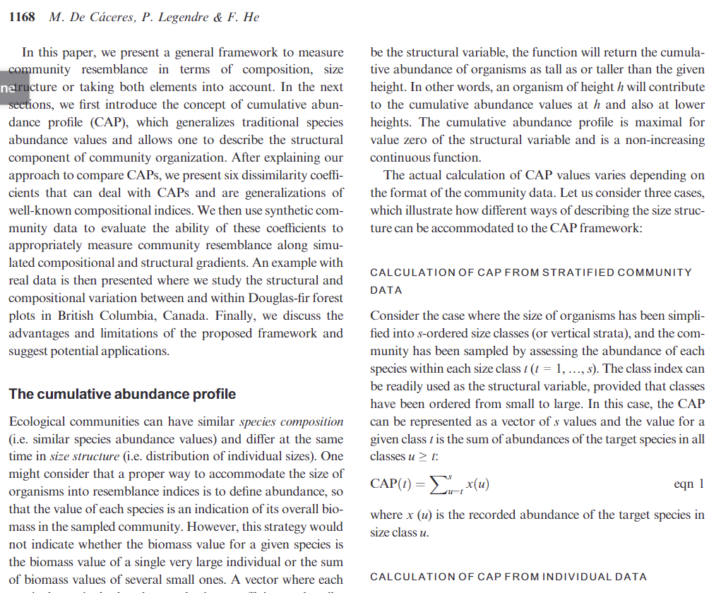

## There is an R package!

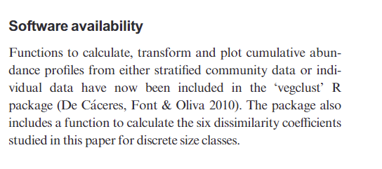

## And it’s documented!

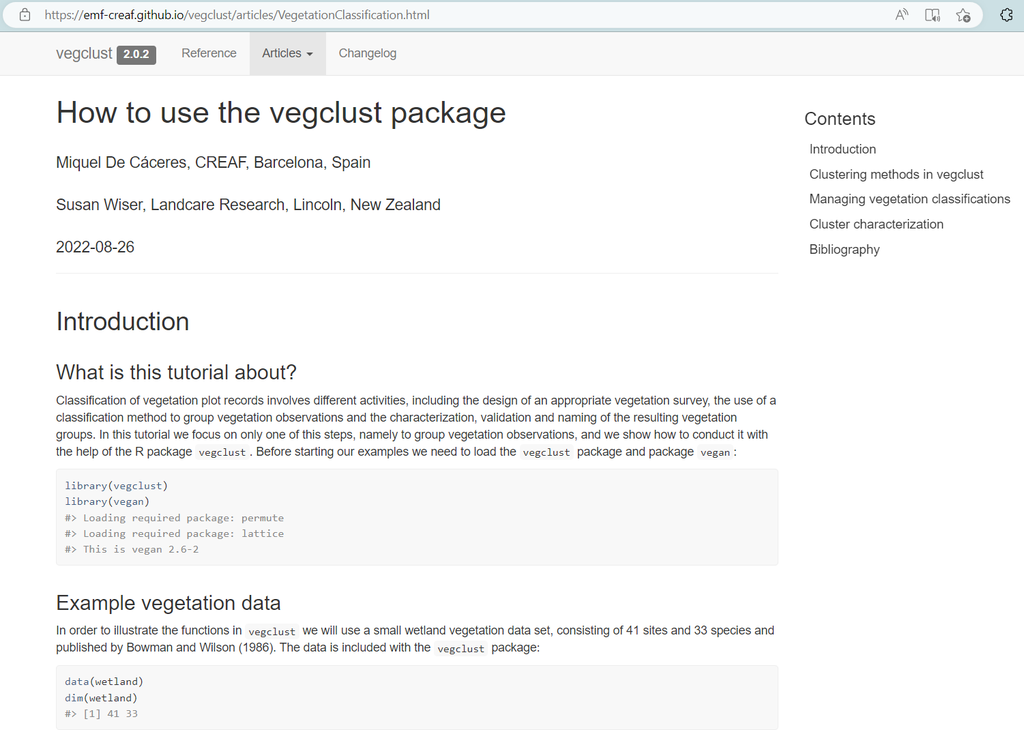

## Reproducibility

- Code and packages are easily shared among collaborators and with broader audiences

[figure not shown]

  Russo, Righelli and Angelini 2016

- It can make your life easier! …or at least make your work more efficient.
  - Revisit past analyses
  - Apply the same analysis to new data

## R basics

## R packages

- Packages are groups of tools, or functions, that contain code and data that allows us to more easily perform specific tasks.
- For example, there are packages that allow for making flexible and customizeable graphs, and others that contain functions to perform a specific type of data analysis or data manipulation.
- While ‘base R’ has a lot of built in functions, one of the strengths of R is that anyone can develop packages and share them with others.

[figure not shown]

## Functions define an action to apply to a set of arguments

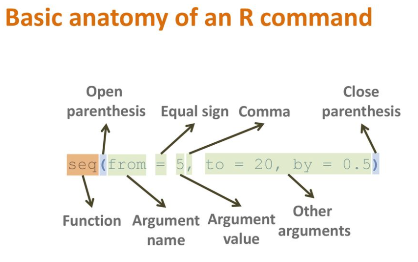

Credit: J. Sebastián Tello Iván Jiménez, https://slideplayer.com/slide/16566948/

```r
seq(from=5, to=20, by=0.5)
```

```
##  [1]  5.0  5.5  6.0  6.5  7.0  7.5  8.0  8.5  9.0  9.5 10.0 10.5 11.0 11.5 12.0
## [16] 12.5 13.0 13.5 14.0 14.5 15.0 15.5 16.0 16.5 17.0 17.5 18.0 18.5 19.0 19.5
## [31] 20.0
```

## R syntax: R objects

```r
myfile <- read.csv(paste0(path, "water_example.csv"))
```

- In this case we use the function, ‘read.csv’ to read in the file, and the function ‘paste0’ to stitch together the text string that we have stored within the ‘path’ object and the name of the file.
- now the data from the .csv file is stored in the object, ‘myfile’

## Vectors & Data Frames

- The most common way of storing data in R and the data structure we’ll deal with most often for analysis is called a ‘data frame’
- Data frames are made up of equal-length vectors
- A ‘vector’ is a sequence of data elements of the same type

```r
# Here is a vector:
vector <- c(0, 2, 4, 5, 7, 2)
vector
```

```
## [1] 0 2 4 5 7 2
```

```r
# Here is a data.frame:
animal <- c("cat", "dog", "horse", "rabbit", "guinea pig", "chicken")
count <- c(7, 6, 5, 1, 2, 2)
df <- data.frame(animal, count)
df
```

```
##       animal count
## 1        cat     7
## 2        dog     6
## 3      horse     5
## 4     rabbit     1
## 5 guinea pig     2
## 6    chicken     2
```

## Anatomy of a Data Frame

[figure not shown]

Credit: https://www.geeksforgeeks.org/r-data-frames/

## Commenting

- Commenting and annotating your code can be really useful and helps document your process

```r
# comments and annotations are made by typing behind a '#' sign
print('you will never be sorry for commenting your code!')
```

```
## [1] "you will never be sorry for commenting your code!"
```

```r
# annotations are often placed before a section of code
print('but they can also be placed on the same line') # like this!
```

```
## [1] "but they can also be placed on the same line"
```

## Reading in data to R

```r
veg <- read.csv(paste0(path, "vegetation_example.csv"))

head(veg)
```

```
##   Transect Azimuth Distance              Species Percent_Cover
## 1        1       0        5 Phalaris arundinacea            50
## 2        1       0        5               Allium             8
## 3        1       0        5             Solidago             4
## 4        1       0        5            Goldenrod             3
## 5        1       0        5                Carex            60
## 6        1       0       10 Phalaris arundinacea            20
```

- text files or .csv files are common
- you have to use the appropriate function to read in your specific file type.

*NOTE: you cannot read in .xlsx files with read.csv()

## R resources for this class

- I’ve created a GitHub repository for this class, where example R scripts and data have been uploaded

[figure not shown]

https://github.com/shlbweiss/UI-Field-Course-at-NGRREC

[figure not shown]

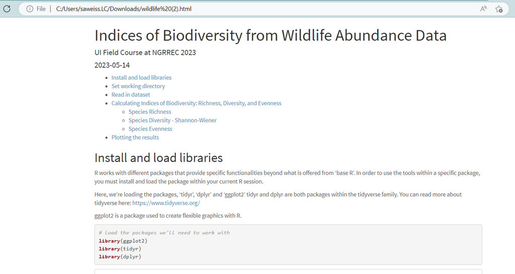